# Demographic and Socioeconomic Determinants of Contraceptive Use Among Women in Bangladesh

#### **Contraceptive using status of women currently in union**

Figure 2 illustrates the distribution of contraceptive method use among women currently in union (married or living together). Modern contraceptive methods are the mostly used by the women, followed by non-use of any method. Traditional methods are used by a smaller proportion of women, while folkloric methods are rarely reported. This pattern indicates a predominance of modern contraceptive use among women in union, although a substantial segment still reports not using any contraception.

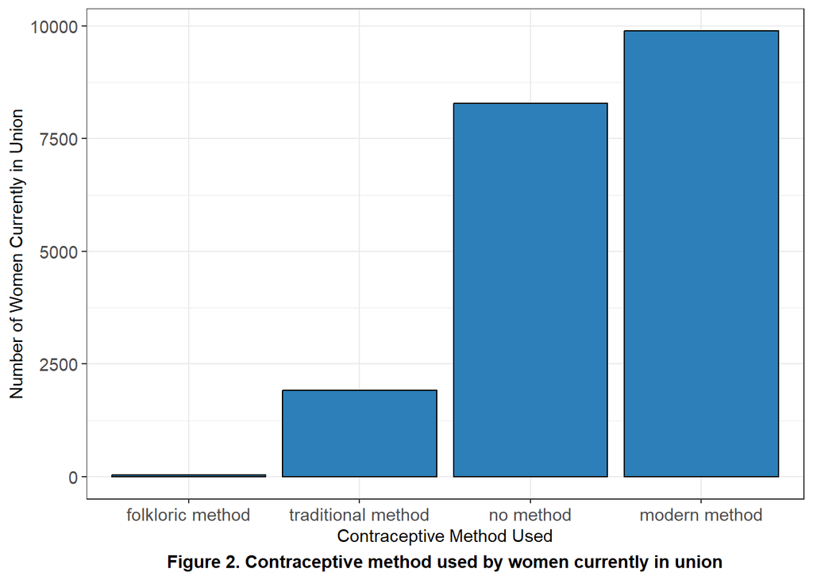

#### **Contraceptive use among different age groups**

The bar chart presents the distribution of contraceptive method use across different age groups in Bangladesh. Use of modern methods is highest among women aged 30–34 and 35–39, while non-use is most prevalent among the youngest (15–19) and oldest (45–49) groups. Traditional method use increases with age, peaking in older groups, whereas folkloric methods are rarely used across all ages. These findings indicate that contraceptive use patterns vary significantly by age, with modern methods favored in mid-reproductive years and lower overall contraceptive use at the extremes of reproductive age (Figure 3).

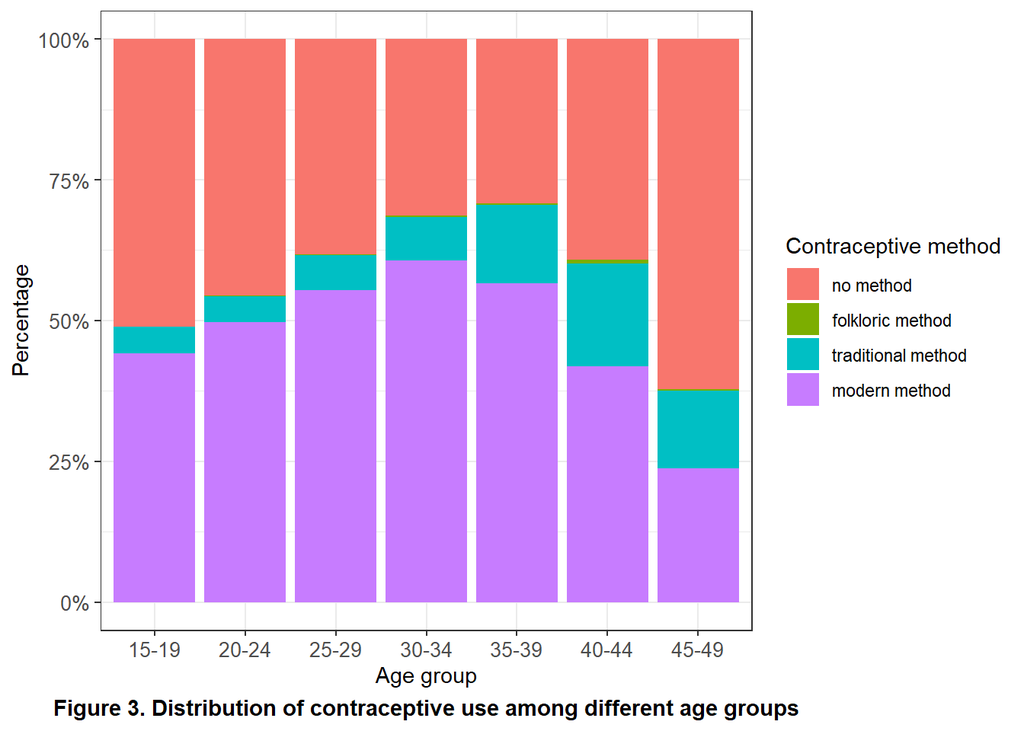